# Supplementary results

# Setup

```r
library(tidyverse)
library(here)
library(kableExtra)
library(glmmTMB)
```

```r
library(broom.mixed)

library(tidygraph)
library(ggraph)
```

```r
source(here("code", "utils", "ggplot_themes.R"))
source(here("code", "utils", "modeling_utils.R"))
source(here("code", "utils", "representation_utils.R"))
source(here("code", "utils", "unicode_greek.R"))

# One-off utils (i.e., written for this script, not general-purpose)
predict_glmmTMB <- function(make_predictions_for, model_object) {
  make_predictions_for %>%
    bind_cols(
      predict(
        object = model_object,
        newdata = .,
        re.form = NA, allow.new.levels = TRUE, se.fit = TRUE, type = "response"
      )
    )
}

check_significance <- function(tidy_df) {
  tidy_df %>%
    mutate(
      sig = case_when(
        p.value < 0.001 ~ "***",
        p.value < 0.01 ~ "**",
        p.value < 0.05 ~ "*",
        p.value < 0.1 ~ ".",
        TRUE ~ ""
      )
    )
}
```

```r
# To control when to save figures
knitting <- knitr::is_html_output()

if (knitting) {
  if (!dir.exists(here("figures"))) {
    dir.create(here("figures"))
  }
}
```

# Memory accuracy

```r
mem_study1 <- here("data", "clean-data", "study1_memory.csv") %>%
  read_csv(show_col_types = FALSE) %>%
  mutate(study = "Study 1", measurement_id = str_c("D", measurement_id)) %>%
  filter(from != to)

mem_study2 <- here("data", "clean-data", "study2_memory.csv") %>%
  read_csv(show_col_types = FALSE) %>%
  mutate(study = "Study 2", measurement_id = str_c("D", measurement_id)) %>%
  filter(from != to)

mem_study3 <- here("data", "clean-data", "study3_memory.csv") %>%
  read_csv(show_col_types = FALSE) %>%
  mutate(
    study = "Study 3",
    measurement_id = case_when(
      measurement_id == 1 ~ "D1",
      measurement_id == 2 ~ "D1b",
      measurement_id == 3 ~ "D2"
    )
  ) %>%
  filter(from != to)
```

## Study 1

We’ll start with study 1. Since this is a one-day study, we’re only interested in testing memory accuracy against chance (50%).

```r
stats_mem_study1 <- mem_study1 %>%
  glmmTMB(
    correct ~ 1 + (1 | sub_id),
    family = binomial,
    data = .
  )

stats_mem_study1 %>%
  tidy() %>%
  kbl(
    caption = str_c(
      "<center>", "Memory: Study 1", "</center>"
    ),
    digits = 3
  ) %>%
  kable_styling(bootstrap_options = c("responsive"))
```

Memory: Study 1

| effect | component | group | term | estimate | std.error | statistic | p.value |
| --- | --- | --- | --- | --- | --- | --- | --- |
| fixed | cond | NA | (Intercept) | 2.364 | 0.147 | 16.057 | 0 |
| ran_pars | cond | sub_id | sd__(Intercept) | 0.980 | NA | NA | NA |

## Study 2

Study 2 was a two-day study, so we’ll test how accuracy changes after overnight rest.

```r
stats_mem_study2 <- mem_study2 %>%
  glmmTMB(
    correct ~ measurement_id + (1 | sub_id),
    family = binomial,
    data = .
  )

stats_mem_study2 %>%
  tidy() %>%
  kbl(
    caption = str_c(
      "<center>", "Memory: Study 2", "</center>"
    ),
    digits = 3
  ) %>%
  kable_styling(bootstrap_options = c("responsive"))
```

Memory: Study 2

| effect | component | group | term | estimate | std.error | statistic | p.value |
| --- | --- | --- | --- | --- | --- | --- | --- |
| fixed | cond | NA | (Intercept) | 2.797 | 0.160 | 17.441 | 0 |
| fixed | cond | NA | measurement_idD2 | -0.246 | 0.058 | -4.285 | 0 |
| ran_pars | cond | sub_id | sd__(Intercept) | 1.067 | NA | NA | NA |

## Study 3

For the primary analysis of interest, we can analyze study 3 just like we analyzed study 2.

```r
stats_mem_study3_overnight_rest <- mem_study3 %>%
  filter(measurement_id %in% c("D1", "D2")) %>%
  glmmTMB(
    correct ~ measurement_id + (1 | sub_id),
    family = binomial,
    data = .
  )

stats_mem_study3_overnight_rest %>%
  tidy() %>%
  kbl(
    caption = str_c(
      "<center>", "Memory: Study 3, overnight rest", "</center>"
    ),
    digits = 3
  ) %>%
  kable_styling(bootstrap_options = c("responsive"))
```

Memory: Study 3, overnight rest

| effect | component | group | term | estimate | std.error | statistic | p.value |
| --- | --- | --- | --- | --- | --- | --- | --- |
| fixed | cond | NA | (Intercept) | 2.768 | 0.215 | 12.868 | 0 |
| fixed | cond | NA | measurement_idD2 | -0.211 | 0.056 | -3.756 | 0 |
| ran_pars | cond | sub_id | sd__(Intercept) | 1.398 | NA | NA | NA |

Study 3 also included an awake rest condition at the end of Day 1. We’ll make “after awake rest” the reference category and compare it against the other measurements (before/after overnight rest).

```r
stats_mem_study3_awake_rest <- mem_study3 %>%
  mutate(measurement_id = fct_relevel(measurement_id, "D1b")) %>%
  glmmTMB(
    correct ~ measurement_id + (1 | sub_id),
    family = binomial,
    data = .
  )

stats_mem_study3_awake_rest %>%
  tidy() %>%
  kbl(
    caption = str_c(
      "<center>", "Memory: Study 3, awake rest", "</center>"
    ),
    digits = 3
  ) %>%
  kable_styling(bootstrap_options = c("responsive"))
```

Memory: Study 3, awake rest

| effect | component | group | term | estimate | std.error | statistic | p.value |
| --- | --- | --- | --- | --- | --- | --- | --- |
| fixed | cond | NA | (Intercept) | 2.639 | 0.227 | 11.645 | 0.000 |
| fixed | cond | NA | measurement_idD1 | 0.166 | 0.057 | 2.936 | 0.003 |
| fixed | cond | NA | measurement_idD2 | -0.045 | 0.055 | -0.821 | 0.411 |
| ran_pars | cond | sub_id | sd__(Intercept) | 1.485 | NA | NA | NA |

# Navigation accuracy

```r
nav_study1 <- here("data", "clean-data", "study1_message_passing.csv") %>%
  read_csv(show_col_types = FALSE) %>%
  filter(
    two_correct_options == FALSE,
    shortest_path_given_opts == shortest_path_given_start_end
  ) %>%
  mutate(
    study = "Study 1",
    measurement_id = str_c("D", measurement_id),
    shortest_path = factor(shortest_path_given_opts)
  ) %>%
  select(
    study, sub_id, measurement_id, shortest_path,
    startpoint_id, endpoint_id,
    opt1_id, opt2_id,
    correct_choice, sub_choice,
    correct, rt
  )

nav_study2 <- here("data", "clean-data", "study2_message_passing.csv") %>%
  read_csv(show_col_types = FALSE) %>%
  filter(
    two_correct_options == FALSE,
    shortest_path_given_opts == shortest_path_given_start_end
  ) %>%
  mutate(
    study = "Study 2",
    measurement_id = case_when(
      network == "learned" ~ str_c("D", measurement_id),
      network == "reevaluated" ~ "D2b"
    ),
    shortest_path = factor(shortest_path_given_opts)
  ) %>%
  select(
    study, sub_id, measurement_id, shortest_path,
    startpoint_id, endpoint_id,
    opt1_id, opt2_id,
    correct_choice, sub_choice,
    correct, rt
  )

nav_study3 <- here("data", "clean-data", "study3_message_passing.csv") %>%
  read_csv(show_col_types = FALSE) %>%
  filter(
    two_correct_options == FALSE,
    shortest_path_given_opts == shortest_path_given_start_end
  ) %>%
  mutate(
    study = "Study 3",
    measurement_id = case_when(
      network == "reevaluated" ~ "D2b",
      measurement_id == 1 ~ "D1",
      measurement_id == 2 ~ "D1b",
      measurement_id == 3 ~ "D2"
    ),
    shortest_path = factor(shortest_path_given_opts)
  ) %>%
  select(
    study, sub_id, measurement_id, shortest_path,
    startpoint_id, endpoint_id,
    opt1_id, opt2_id,
    correct_choice, sub_choice,
    correct, rt
  )
```

## Navigation before overnight rest

We want to know whether navigation accuracy is different from chance at each distance, so we’ll iteratively reparameterize the model so that each distance is the reference category.

We’ll start with study 1. Note that estimating a random slope leads to model convergence problems in studies 2-3, so we’ll only be estimating a random intercept per subject.

```r
stats_nav_study1_dist2 <- nav_study1 %>%
  mutate(shortest_path = fct_relevel(shortest_path, "2")) %>%
  glmmTMB(
    correct ~ shortest_path + (1 | sub_id),
    family = binomial,
    data = .
  )

stats_nav_study1_dist3 <- nav_study1 %>%
  mutate(shortest_path = fct_relevel(shortest_path, "3")) %>%
  glmmTMB(
    correct ~ shortest_path + (1 | sub_id),
    family = binomial,
    data = .
  )

stats_nav_study1_dist4 <- nav_study1 %>%
  mutate(shortest_path = fct_relevel(shortest_path, "4")) %>%
  glmmTMB(
    correct ~ shortest_path + (1  | sub_id),
    family = binomial,
    data = .
  )

map_dfr(
  .x = list(
    "dist-2" = stats_nav_study1_dist2,
    "dist-3" = stats_nav_study1_dist3,
    "dist-4" = stats_nav_study1_dist4
  ),
  .f = ~tidy(.x, conf.int = TRUE),
  .id = "ref_cat"
) %>%
  check_significance() %>%
  select(-c(group, ref_cat, effect, component)) %>%
  kbl(
    caption = str_c(
      "<center>", "Navigation accuracy: Day 1, Study 1", "</center>"
    ),
    digits = 3
  ) %>%
  kable_styling(bootstrap_options = c("responsive")) %>%
  pack_rows("Ref. Cat. dist-2", 1, 4) %>%
  pack_rows("Ref. Cat. dist-3", 5, 8) %>%
  pack_rows("Ref. Cat. dist-4", 9, 12)
```

Navigation accuracy: Day 1, Study 1

| term | estimate | std.error | statistic | p.value | conf.low | conf.high | sig |
| --- | --- | --- | --- | --- | --- | --- | --- |
| **Ref. Cat. dist-2** |  |  |  |  |  |  |  |
| (Intercept) | 1.343 | 0.105 | 12.758 | 0 | 1.137 | 1.550 | *** |
| shortest_path3 | -0.656 | 0.074 | -8.898 | 0 | -0.800 | -0.511 | *** |
| shortest_path4 | -0.931 | 0.072 | -12.924 | 0 | -1.072 | -0.790 | *** |
| sd__(Intercept) | 0.659 | NA | NA | NA | 0.523 | 0.830 |  |
| **Ref. Cat. dist-3** |  |  |  |  |  |  |  |
| (Intercept) | 0.688 | 0.109 | 6.294 | 0 | 0.474 | 0.902 | *** |
| shortest_path2 | 0.656 | 0.074 | 8.898 | 0 | 0.511 | 0.800 | *** |
| shortest_path4 | -0.275 | 0.078 | -3.532 | 0 | -0.428 | -0.123 | *** |
| sd__(Intercept) | 0.659 | NA | NA | NA | 0.523 | 0.830 |  |
| **Ref. Cat. dist-4** |  |  |  |  |  |  |  |
| (Intercept) | 0.412 | 0.108 | 3.821 | 0 | 0.201 | 0.624 | *** |
| shortest_path2 | 0.931 | 0.072 | 12.924 | 0 | 0.790 | 1.072 | *** |
| shortest_path3 | 0.275 | 0.078 | 3.532 | 0 | 0.123 | 0.428 | *** |
| sd__(Intercept) | 0.659 | NA | NA | NA | 0.523 | 0.830 |  |

Moving on to study 2:

```r
stats_nav_study2_day1_dist2 <- nav_study2 %>%
  filter(measurement_id == "D1") %>%
  mutate(shortest_path = fct_relevel(shortest_path, "2")) %>%
  glmmTMB(
    correct ~ shortest_path + (1 | sub_id),
    family = binomial,
    data = .
  )

stats_nav_study2_day1_dist3 <- nav_study2 %>%
  filter(measurement_id == "D1") %>%
  mutate(shortest_path = fct_relevel(shortest_path, "3")) %>%
  glmmTMB(
    correct ~ shortest_path + (1 | sub_id),
    family = binomial,
    data = .
  )

stats_nav_study2_day1_dist4 <- nav_study2 %>%
  filter(measurement_id == "D1") %>%
  mutate(shortest_path = fct_relevel(shortest_path, "4")) %>%
  glmmTMB(
    correct ~ shortest_path + (1 | sub_id),
    family = binomial,
    data = .
  )

map_dfr(
  .x = list(
    "dist-2" = stats_nav_study2_day1_dist2,
    "dist-3" = stats_nav_study2_day1_dist3,
    "dist-4" = stats_nav_study2_day1_dist4
  ),
  .f = ~tidy(.x, conf.int = TRUE),
  .id = "ref_cat"
) %>%
  check_significance() %>%
  select(-c(group, ref_cat, effect, component)) %>%
  kbl(
    caption = str_c(
      "<center>", "Navigation accuracy: Day 1, Study 2", "</center>"
    ),
    digits = 3
  ) %>%
  kable_styling(bootstrap_options = c("responsive")) %>%
  pack_rows("Ref. Cat. dist-2", 1, 4) %>%
  pack_rows("Ref. Cat. dist-3", 5, 8) %>%
  pack_rows("Ref. Cat. dist-4", 9, 12)
```

Navigation accuracy: Day 1, Study 2

| term | estimate | std.error | statistic | p.value | conf.low | conf.high | sig |
| --- | --- | --- | --- | --- | --- | --- | --- |
| **Ref. Cat. dist-2** |  |  |  |  |  |  |  |
| (Intercept) | 1.712 | 0.134 | 12.774 | 0 | 1.449 | 1.975 | *** |
| shortest_path3 | -0.574 | 0.080 | -7.172 | 0 | -0.731 | -0.417 | *** |
| shortest_path4 | -1.012 | 0.077 | -13.151 | 0 | -1.162 | -0.861 | *** |
| sd__(Intercept) | 0.861 | NA | NA | NA | 0.686 | 1.082 |  |
| **Ref. Cat. dist-3** |  |  |  |  |  |  |  |
| (Intercept) | 1.138 | 0.137 | 8.281 | 0 | 0.868 | 1.407 | *** |
| shortest_path2 | 0.574 | 0.080 | 7.172 | 0 | 0.417 | 0.731 | *** |
| shortest_path4 | -0.437 | 0.083 | -5.264 | 0 | -0.600 | -0.274 | *** |
| sd__(Intercept) | 0.861 | NA | NA | NA | 0.686 | 1.082 |  |
| **Ref. Cat. dist-4** |  |  |  |  |  |  |  |
| (Intercept) | 0.700 | 0.135 | 5.187 | 0 | 0.436 | 0.965 | *** |
| shortest_path2 | 1.012 | 0.077 | 13.151 | 0 | 0.861 | 1.162 | *** |
| shortest_path3 | 0.437 | 0.083 | 5.264 | 0 | 0.274 | 0.600 | *** |
| sd__(Intercept) | 0.861 | NA | NA | NA | 0.686 | 1.082 |  |

And finally study 3:

```r
stats_nav_study3_day1_dist2 <- nav_study3 %>%
  filter(measurement_id == "D1") %>%
  mutate(shortest_path = fct_relevel(shortest_path, "2")) %>%
  glmmTMB(
    correct ~ shortest_path + (1 | sub_id),
    family = binomial,
    data = .
  )

stats_nav_study3_day1_dist3 <- nav_study3 %>%
  filter(measurement_id == "D1") %>%
  mutate(shortest_path = fct_relevel(shortest_path, "3")) %>%
  glmmTMB(
    correct ~ shortest_path + (1 | sub_id),
    family = binomial,
    data = .
  )

stats_nav_study3_day1_dist4 <- nav_study3 %>%
  filter(measurement_id == "D1") %>%
  mutate(shortest_path = fct_relevel(shortest_path, "4")) %>%
  glmmTMB(
    correct ~ shortest_path + (1 | sub_id),
    family = binomial,
    data = .
  )

map_dfr(
  .x = list(
    "dist-2" = stats_nav_study3_day1_dist2,
    "dist-3" = stats_nav_study3_day1_dist3,
    "dist-4" = stats_nav_study3_day1_dist4
  ),
  .f = ~tidy(.x, conf.int = TRUE),
  .id = "ref_cat"
) %>%
  check_significance() %>%
  select(-c(group, ref_cat, effect, component)) %>%
  kbl(
    caption = str_c(
      "<center>", "Navigation accuracy: Day 1, Study 3", "</center>"
    ),
    digits = 3
  ) %>%
  kable_styling(bootstrap_options = c("responsive")) %>%
  pack_rows("Ref. Cat. dist-2", 1, 4) %>%
  pack_rows("Ref. Cat. dist-3", 5, 8) %>%
  pack_rows("Ref. Cat. dist-4", 9, 12)
```

Navigation accuracy: Day 1, Study 3

| term | estimate | std.error | statistic | p.value | conf.low | conf.high | sig |
| --- | --- | --- | --- | --- | --- | --- | --- |
| **Ref. Cat. dist-2** |  |  |  |  |  |  |  |
| (Intercept) | 1.813 | 0.186 | 9.757 | 0 | 1.449 | 2.178 | *** |
| shortest_path3 | -0.459 | 0.085 | -5.365 | 0 | -0.626 | -0.291 | *** |
| shortest_path4 | -0.921 | 0.082 | -11.213 | 0 | -1.082 | -0.760 | *** |
| sd__(Intercept) | 1.182 | NA | NA | NA | 0.929 | 1.504 |  |
| **Ref. Cat. dist-3** |  |  |  |  |  |  |  |
| (Intercept) | 1.355 | 0.189 | 7.160 | 0 | 0.984 | 1.726 | *** |
| shortest_path2 | 0.459 | 0.085 | 5.365 | 0 | 0.291 | 0.626 | *** |
| shortest_path4 | -0.463 | 0.090 | -5.129 | 0 | -0.639 | -0.286 | *** |
| sd__(Intercept) | 1.182 | NA | NA | NA | 0.929 | 1.504 |  |
| **Ref. Cat. dist-4** |  |  |  |  |  |  |  |
| (Intercept) | 0.892 | 0.187 | 4.770 | 0 | 0.526 | 1.259 | *** |
| shortest_path2 | 0.921 | 0.082 | 11.213 | 0 | 0.760 | 1.082 | *** |
| shortest_path3 | 0.463 | 0.090 | 5.129 | 0 | 0.286 | 0.639 | *** |
| sd__(Intercept) | 1.182 | NA | NA | NA | 0.929 | 1.504 |  |

## Navigation after overnight rest

In studies 2-3, subjects returned to the lab after overnight rest. The primary analysis of interest is to test whether there is evidence of navigation accuracy increasing. Because we’re interested in addressing this question for each distance, we’ll be iteratively reparameterizing the models so that each distance is the reference category.

```r
stats_nav_study2_day2_dist2 <- nav_study2 %>%
  filter(measurement_id %in% c("D1", "D2")) %>%
  mutate(shortest_path = fct_relevel(shortest_path, "2")) %>%
  glmmTMB(
    correct ~ measurement_id * shortest_path + (1 + measurement_id | sub_id),
    family = binomial,
    data = .
  )

stats_nav_study2_day2_dist3 <- nav_study2 %>%
  filter(measurement_id %in% c("D1", "D2")) %>%
  mutate(shortest_path = fct_relevel(shortest_path, "3")) %>%
  glmmTMB(
    correct ~ measurement_id * shortest_path + (1 + measurement_id | sub_id),
    family = binomial,
    data = .
  )

stats_nav_study2_day2_dist4 <- nav_study2 %>%
  filter(measurement_id %in% c("D1", "D2")) %>%
  mutate(shortest_path = fct_relevel(shortest_path, "4")) %>%
  glmmTMB(
    correct ~ measurement_id * shortest_path + (1 + measurement_id | sub_id),
    family = binomial,
    data = .
  )

map_dfr(
  .x = list(
    "dist-2" = stats_nav_study2_day2_dist2,
    "dist-3" = stats_nav_study2_day2_dist3,
    "dist-4" = stats_nav_study2_day2_dist4
  ),
  .f = ~tidy(.x, conf.int = TRUE),
  .id = "ref_cat"
) %>%
  check_significance() %>%
  select(-c(group, ref_cat, effect, component)) %>%
  kbl(
    caption = str_c(
      "<center>", "Navigation accuracy: Day 2, Study 2", "</center>"
    ),
    digits = 3
  ) %>%
  kable_styling(bootstrap_options = c("responsive")) %>%
  pack_rows("Ref. Cat. dist-2", 1, 9) %>%
  pack_rows("Ref. Cat. dist-3", 10, 18) %>%
  pack_rows("Ref. Cat. dist-4", 19, 27)
```

Navigation accuracy: Day 2, Study 2

term

estimate

std.error

statistic

p.value

conf.low

conf.high

sig

**Ref. Cat. dist-2**

(Intercept)

1.716

0.135

12.676

0.000

1.450

1.981

***

measurement_idD2

0.193

0.104

1.858

0.063

-0.011

0.397

.

shortest_path3

-0.574

0.080

-7.170

0.000

-0.731

-0.417

***

shortest_path4

-1.011

0.077

-13.149

0.000

-1.162

-0.861

***

measurement_idD2:shortest_path3

0.131

0.116

1.130

0.258

-0.097

0.359

measurement_idD2:shortest_path4

0.239

0.112

2.139

0.032

0.020

0.459

sd__(Intercept)

0.872

NA

NA

NA

0.695

1.094

sd__measurement_idD2

0.445

NA

NA

NA

0.314

0.631

cor__(Intercept).measurement_idD2

0.484

NA

NA

NA

-0.019

0.747

**Ref. Cat. dist-3**

(Intercept)

1.141

0.139

8.233

0.000

0.870

1.413

***

measurement_idD2

0.325

0.114

2.857

0.004

0.102

0.548

shortest_path2

0.574

0.080

7.170

0.000

0.417

0.731

***

shortest_path4

-0.437

0.083

-5.263

0.000

-0.600

-0.274

***

measurement_idD2:shortest_path2

-0.132

0.116

-1.130

0.258

-0.360

0.097

measurement_idD2:shortest_path4

0.108

0.122

0.885

0.376

-0.131

0.346

sd__(Intercept)

0.872

NA

NA

NA

0.695

1.094

sd__measurement_idD2

0.445

NA

NA

NA

0.314

0.631

cor__(Intercept).measurement_idD2

0.484

NA

NA

NA

-0.019

0.747

**Ref. Cat. dist-4**

(Intercept)

0.704

0.136

5.166

0.000

0.437

0.971

***

measurement_idD2

0.433

0.108

4.019

0.000

0.222

0.644

***

shortest_path2

1.011

0.077

13.149

0.000

0.861

1.162

***

shortest_path3

0.437

0.083

5.264

0.000

0.274

0.600

***

measurement_idD2:shortest_path2

-0.239

0.112

-2.139

0.032

-0.459

-0.020

measurement_idD2:shortest_path3

-0.108

0.122

-0.885

0.376

-0.346

0.131

sd__(Intercept)

0.872

NA

NA

NA

0.695

1.094

sd__measurement_idD2

0.445

NA

NA

NA

0.314

0.631

cor__(Intercept).measurement_idD2

0.484

NA

NA

NA

-0.019

0.747

We’ll do the same for study 3.

```r
stats_nav_study3_day2_dist2 <- nav_study3 %>%
  filter(measurement_id %in% c("D1", "D2")) %>%
  mutate(shortest_path = fct_relevel(shortest_path, "2")) %>%
  glmmTMB(
    correct ~ measurement_id * shortest_path + (1 + measurement_id | sub_id),
    family = binomial,
    data = .
  )

stats_nav_study3_day2_dist3 <- nav_study3 %>%
  filter(measurement_id %in% c("D1", "D2")) %>%
  mutate(shortest_path = fct_relevel(shortest_path, "3")) %>%
  glmmTMB(
    correct ~ measurement_id * shortest_path + (1 + measurement_id | sub_id),
    family = binomial,
    data = .
  )

stats_nav_study3_day2_dist4 <- nav_study3 %>%
  filter(measurement_id %in% c("D1", "D2")) %>%
  mutate(shortest_path = fct_relevel(shortest_path, "4")) %>%
  glmmTMB(
    correct ~ measurement_id * shortest_path + (1 + measurement_id | sub_id),
    family = binomial,
    data = .
  )

map_dfr(
  .x = list(
    "dist-2" = stats_nav_study3_day2_dist2,
    "dist-3" = stats_nav_study3_day2_dist3,
    "dist-4" = stats_nav_study3_day2_dist4
  ),
  .f = ~tidy(.x, conf.int = TRUE),
  .id = "ref_cat"
) %>%
  check_significance() %>%
  select(-c(group, ref_cat, effect, component)) %>%
  kbl(
    caption = str_c(
      "<center>", "Navigation accuracy: Day 2, Study 3", "</center>"
    ),
    digits = 3
  ) %>%
  kable_styling(bootstrap_options = c("responsive")) %>%
  pack_rows("Ref. Cat. dist-2", 1, 9) %>%
  pack_rows("Ref. Cat. dist-3", 10, 18) %>%
  pack_rows("Ref. Cat. dist-4", 19, 27)
```

Navigation accuracy: Day 2, Study 3

term

estimate

std.error

statistic

p.value

conf.low

conf.high

sig

**Ref. Cat. dist-2**

(Intercept)

1.823

0.190

9.596

0.000

1.451

2.196

***

measurement_idD2

0.293

0.124

2.365

0.018

0.050

0.535

shortest_path3

-0.458

0.085

-5.362

0.000

-0.625

-0.291

***

shortest_path4

-0.920

0.082

-11.207

0.000

-1.081

-0.759

***

measurement_idD2:shortest_path3

-0.146

0.123

-1.187

0.235

-0.386

0.095

measurement_idD2:shortest_path4

0.157

0.119

1.320

0.187

-0.076

0.391

sd__(Intercept)

1.212

NA

NA

NA

0.954

1.541

sd__measurement_idD2

0.517

NA

NA

NA

0.341

0.785

cor__(Intercept).measurement_idD2

0.536

NA

NA

NA

-0.014

0.788

**Ref. Cat. dist-3**

(Intercept)

1.365

0.193

7.063

0.000

0.986

1.744

***

measurement_idD2

0.147

0.133

1.110

0.267

-0.113

0.407

shortest_path2

0.458

0.085

5.362

0.000

0.291

0.625

***

shortest_path4

-0.462

0.090

-5.127

0.000

-0.639

-0.285

***

measurement_idD2:shortest_path2

0.146

0.123

1.187

0.235

-0.095

0.386

measurement_idD2:shortest_path4

0.303

0.130

2.330

0.020

0.048

0.558

sd__(Intercept)

1.212

NA

NA

NA

0.954

1.541

sd__measurement_idD2

0.517

NA

NA

NA

0.341

0.785

cor__(Intercept).measurement_idD2

0.536

NA

NA

NA

-0.013

0.788

**Ref. Cat. dist-4**

(Intercept)

0.903

0.191

4.725

0.000

0.528

1.278

***

measurement_idD2

0.450

0.128

3.528

0.000

0.200

0.700

***

shortest_path2

0.920

0.082

11.207

0.000

0.759

1.081

***

shortest_path3

0.462

0.090

5.127

0.000

0.285

0.639

***

measurement_idD2:shortest_path2

-0.157

0.119

-1.320

0.187

-0.391

0.076

measurement_idD2:shortest_path3

-0.303

0.130

-2.330

0.020

-0.558

-0.048

sd__(Intercept)

1.212

NA

NA

NA

0.954

1.541

sd__measurement_idD2

0.517

NA

NA

NA

0.341

0.785

cor__(Intercept).measurement_idD2

0.536

NA

NA

NA

-0.013

0.788

## Navigation after awake rest

In study 3, we tested whether a brief period of awake rest was sufficient for improving navigation accuracy.

```r
stats_nav_awake_rest_dist2 <- nav_study3 %>%
  filter(measurement_id %in% c("D1", "D1b")) %>%
  mutate(shortest_path = fct_relevel(shortest_path, "2")) %>%
  glmmTMB(
    correct ~ measurement_id * shortest_path +
      (1 + measurement_id + shortest_path | sub_id),
    family = binomial,
    data = .
  )

stats_nav_awake_rest_dist3 <- nav_study3 %>%
  filter(measurement_id %in% c("D1", "D1b")) %>%
  mutate(shortest_path = fct_relevel(shortest_path, "3")) %>%
  glmmTMB(
    correct ~ measurement_id * shortest_path +
      (1 + measurement_id + shortest_path | sub_id),
    family = binomial,
    data = .
  )

stats_nav_awake_rest_dist4 <- nav_study3 %>%
  filter(measurement_id %in% c("D1", "D1b")) %>%
  mutate(shortest_path = fct_relevel(shortest_path, "4")) %>%
  glmmTMB(
    correct ~ measurement_id * shortest_path +
      (1 + measurement_id + shortest_path | sub_id),
    family = binomial,
    data = .
  )

map_dfr(
  .x = list(
    "dist-2" = stats_nav_awake_rest_dist2,
    "dist-3" = stats_nav_awake_rest_dist3,
    "dist-4" = stats_nav_awake_rest_dist4
  ),
  .f = ~tidy(.x, conf.int = TRUE),
  .id = "ref_cat"
) %>%
  check_significance() %>%
  select(-c(group, ref_cat, effect, component)) %>%
  kbl(
    caption = str_c(
      "<center>", "Navigation accuracy: After awake rest", "</center>"
    ),
    digits = 3
  ) %>%
  kable_styling(bootstrap_options = c("responsive")) %>%
  pack_rows("Ref. Cat. dist-2", 1, 16) %>%
  pack_rows("Ref. Cat. dist-3", 17, 32) %>%
  pack_rows("Ref. Cat. dist-4", 33, 48)
```

Navigation accuracy: After awake rest

term

estimate

std.error

statistic

p.value

conf.low

conf.high

sig

**Ref. Cat. dist-2**

(Intercept)

1.840

0.193

9.542

0.000

1.462

2.218

***

measurement_idD1b

-0.058

0.122

-0.475

0.635

-0.296

0.181

shortest_path3

-0.424

0.129

-3.290

0.001

-0.677

-0.171

shortest_path4

-0.936

0.134

-6.971

0.000

-1.199

-0.673

***

measurement_idD1b:shortest_path3

0.022

0.123

0.175

0.861

-0.220

0.263

measurement_idD1b:shortest_path4

0.244

0.119

2.060

0.039

0.012

0.477

sd__(Intercept)

1.216

NA

NA

NA

0.947

1.561

sd__measurement_idD1b

0.544

NA

NA

NA

0.395

0.751

sd__shortest_path3

0.518

NA

NA

NA

0.352

0.764

sd__shortest_path4

0.632

NA

NA

NA

0.465

0.859

cor__(Intercept).measurement_idD1b

0.045

NA

NA

NA

-0.376

0.445

cor__(Intercept).shortest_path3

-0.019

NA

NA

NA

-0.453

0.374

cor__(Intercept).shortest_path4

-0.262

NA

NA

NA

-0.767

0.123

cor__measurement_idD1b.shortest_path3

0.191

NA

NA

NA

-0.072

0.642

cor__measurement_idD1b.shortest_path4

-0.024

NA

NA

NA

-0.137

0.261

cor__shortest_path3.shortest_path4

0.845

NA

NA

NA

0.453

0.879

**Ref. Cat. dist-3**

(Intercept)

1.416

0.211

6.714

0.000

1.002

1.829

***

measurement_idD1b

-0.036

0.133

-0.273

0.785

-0.296

0.224

shortest_path2

0.424

0.129

3.290

0.001

0.172

0.677

shortest_path4

-0.512

0.116

-4.428

0.000

-0.738

-0.285

***

measurement_idD1b:shortest_path2

-0.022

0.123

-0.175

0.861

-0.263

0.219

measurement_idD1b:shortest_path4

0.223

0.129

1.723

0.085

-0.031

0.476

.

sd__(Intercept)

1.313

NA

NA

NA

1.010

1.705

sd__measurement_idD1b

0.544

NA

NA

NA

0.395

0.751

sd__shortest_path2

0.518

NA

NA

NA

0.352

0.764

sd__shortest_path4

0.338

NA

NA

NA

0.190

0.603

cor__(Intercept).measurement_idD1b

0.117

NA

NA

NA

-0.340

0.513

cor__(Intercept).shortest_path2

-0.377

NA

NA

NA

-0.647

0.171

cor__(Intercept).shortest_path4

-0.408

NA

NA

NA

-0.606

0.363

cor__measurement_idD1b.shortest_path2

-0.191

NA

NA

NA

-0.167

0.344

cor__measurement_idD1b.shortest_path4

-0.337

NA

NA

NA

-0.229

0.455

cor__shortest_path2.shortest_path4

-0.046

NA

NA

NA

0.261

0.560

**Ref. Cat. dist-4**

(Intercept)

0.904

0.193

4.684

0.000

0.526

1.283

***

measurement_idD1b

0.187

0.126

1.477

0.140

-0.061

0.434

shortest_path2

0.936

0.134

6.972

0.000

0.673

1.199

***

shortest_path3

0.512

0.116

4.428

0.000

0.285

0.738

***

measurement_idD1b:shortest_path2

-0.244

0.119

-2.060

0.039

-0.477

-0.012

measurement_idD1b:shortest_path3

-0.223

0.129

-1.723

0.085

-0.476

0.031

.

sd__(Intercept)

1.214

NA

NA

NA

0.935

1.577

sd__measurement_idD1b

0.544

NA

NA

NA

0.395

0.751

sd__shortest_path2

0.632

NA

NA

NA

0.465

0.859

sd__shortest_path3

0.338

NA

NA

NA

0.190

0.603

cor__(Intercept).measurement_idD1b

0.033

NA

NA

NA

-0.406

0.454

cor__(Intercept).shortest_path2

-0.258

NA

NA

NA

-0.575

0.197

cor__(Intercept).shortest_path3

0.163

NA

NA

NA

-0.618

0.460

cor__measurement_idD1b.shortest_path2

0.024

NA

NA

NA

-0.040

0.454

cor__measurement_idD1b.shortest_path3

0.337

NA

NA

NA

-0.072

0.654

cor__shortest_path2.shortest_path3

0.573

NA

NA

NA

0.408

0.875

## Navigation after reevaluation

In studies 2-3, we tested for evidence of cached representations using a transition reevaluation paradigm.

We’ll start by looking at study 2…

```r
stats_nav_study2_tr_dist2 <- nav_study2 %>%
  mutate(
    shortest_path = fct_relevel(shortest_path, "2"),
    measurement_id = fct_relevel(measurement_id, "D2b")
  ) %>%
  glmmTMB(
    correct ~ measurement_id * shortest_path + (1 + measurement_id | sub_id),
    family = binomial,
    data = .
  )

stats_nav_study2_tr_dist3 <- nav_study2 %>%
  mutate(
    shortest_path = fct_relevel(shortest_path, "3"),
    measurement_id = fct_relevel(measurement_id, "D2b")
  ) %>%
  glmmTMB(
    correct ~ measurement_id * shortest_path + (1 + measurement_id | sub_id),
    family = binomial,
    data = .
  )

stats_nav_study2_tr_dist4 <- nav_study2 %>%
  mutate(
    shortest_path = fct_relevel(shortest_path, "4"),
    measurement_id = fct_relevel(measurement_id, "D2b")
  ) %>%
  glmmTMB(
    correct ~ measurement_id * shortest_path + (1 + measurement_id | sub_id),
    family = binomial,
    data = .
  )

map_dfr(
  .x = list(
    "dist-2" = stats_nav_study2_tr_dist2,
    "dist-3" = stats_nav_study2_tr_dist3,
    "dist-4" = stats_nav_study2_tr_dist4
  ),
  .f = ~tidy(.x, conf.int = TRUE),
  .id = "ref_cat"
) %>%
  check_significance() %>%
  select(-c(group, ref_cat, effect, component)) %>%
  kbl(
    caption = str_c(
      "<center>", "Navigation accuracy: Reevaluation, Study 2", "</center>"
    ),
    digits = 3
  ) %>%
  kable_styling(bootstrap_options = c("responsive")) %>%
  pack_rows("Ref. Cat. dist-2", 1, 15) %>%
  pack_rows("Ref. Cat. dist-3", 16, 30) %>%
  pack_rows("Ref. Cat. dist-4", 31, 45)
```

Navigation accuracy: Reevaluation, Study 2

term

estimate

std.error

statistic

p.value

conf.low

conf.high

sig

**Ref. Cat. dist-2**

(Intercept)

1.841

0.180

10.255

0.000

1.490

2.193

***

measurement_idD1

-0.119

0.116

-1.026

0.305

-0.348

0.109

measurement_idD2

0.090

0.110

0.818

0.413

-0.125

0.305

shortest_path3

-0.653

0.073

-8.931

0.000

-0.796

-0.509

***

shortest_path4

-1.259

0.072

-17.377

0.000

-1.401

-1.117

***

measurement_idD1:shortest_path3

0.079

0.108

0.729

0.466

-0.133

0.291

measurement_idD2:shortest_path3

0.211

0.112

1.889

0.059

-0.008

0.430

.

measurement_idD1:shortest_path4

0.249

0.106

2.355

0.019

0.042

0.456

measurement_idD2:shortest_path4

0.489

0.109

4.489

0.000

0.275

0.702

***

sd__(Intercept)

1.200

NA

NA

NA

0.956

1.508

sd__measurement_idD1

0.595

NA

NA

NA

0.441

0.803

sd__measurement_idD2

0.491

NA

NA

NA

0.363

0.665

cor__(Intercept).measurement_idD1

-0.697

NA

NA

NA

-0.842

-0.358

cor__(Intercept).measurement_idD2

-0.169

NA

NA

NA

-0.667

0.213

cor__measurement_idD1.measurement_idD2

0.630

NA

NA

NA

0.688

0.718

**Ref. Cat. dist-3**

(Intercept)

1.189

0.180

6.607

0.000

0.836

1.541

***

measurement_idD1

-0.040

0.121

-0.335

0.738

-0.277

0.196

measurement_idD2

0.301

0.116

2.601

0.009

0.074

0.527

shortest_path2

0.653

0.073

8.931

0.000

0.509

0.796

***

shortest_path4

-0.607

0.074

-8.200

0.000

-0.752

-0.462

***

measurement_idD1:shortest_path2

-0.079

0.108

-0.729

0.466

-0.291

0.133

measurement_idD2:shortest_path2

-0.211

0.112

-1.889

0.059

-0.430

0.008

.

measurement_idD1:shortest_path4

0.170

0.111

1.527

0.127

-0.048

0.388

measurement_idD2:shortest_path4

0.278

0.116

2.400

0.016

0.051

0.505

sd__(Intercept)

1.200

NA

NA

NA

0.956

1.508

sd__measurement_idD1

0.595

NA

NA

NA

0.441

0.803

sd__measurement_idD2

0.491

NA

NA

NA

0.363

0.665

cor__(Intercept).measurement_idD1

-0.697

NA

NA

NA

-0.842

-0.358

cor__(Intercept).measurement_idD2

-0.169

NA

NA

NA

-0.667

0.213

cor__measurement_idD1.measurement_idD2

0.630

NA

NA

NA

0.688

0.718

**Ref. Cat. dist-4**

(Intercept)

0.582

0.179

3.253

0.001

0.231

0.933

measurement_idD1

0.129

0.117

1.109

0.267

-0.099

0.358

measurement_idD2

0.578

0.111

5.213

0.000

0.361

0.796

***

shortest_path2

1.259

0.072

17.377

0.000

1.117

1.401

***

shortest_path3

0.607

0.074

8.200

0.000

0.462

0.752

***

measurement_idD1:shortest_path2

-0.249

0.106

-2.355

0.019

-0.456

-0.042

measurement_idD2:shortest_path2

-0.489

0.109

-4.489

0.000

-0.702

-0.275

***

measurement_idD1:shortest_path3

-0.170

0.111

-1.527

0.127

-0.388

0.048

measurement_idD2:shortest_path3

-0.278

0.116

-2.400

0.016

-0.505

-0.051

sd__(Intercept)

1.200

NA

NA

NA

0.956

1.508

sd__measurement_idD1

0.595

NA

NA

NA

0.441

0.803

sd__measurement_idD2

0.491

NA

NA

NA

0.363

0.665

cor__(Intercept).measurement_idD1

-0.697

NA

NA

NA

-0.842

-0.358

cor__(Intercept).measurement_idD2

-0.169

NA

NA

NA

-0.667

0.213

cor__measurement_idD1.measurement_idD2

0.630

NA

NA

NA

0.688

0.718

And we’ll do the same for study 3…

```r
stats_nav_study3_tr_dist2 <- nav_study3 %>%
  filter(measurement_id %in% c("D1", "D2", "D2b")) %>%
  mutate(
    shortest_path = fct_relevel(shortest_path, "2"),
    measurement_id = fct_relevel(measurement_id, "D2b")
  ) %>%
  glmmTMB(
    correct ~ measurement_id * shortest_path + (1 + measurement_id | sub_id),
    family = binomial,
    data = .
  )

stats_nav_study3_tr_dist3 <- nav_study3 %>%
  filter(measurement_id %in% c("D1", "D2", "D2b")) %>%
  mutate(
    shortest_path = fct_relevel(shortest_path, "3"),
    measurement_id = fct_relevel(measurement_id, "D2b")
  ) %>%
  glmmTMB(
    correct ~ measurement_id * shortest_path + (1 + measurement_id | sub_id),
    family = binomial,
    data = .
  )

stats_nav_study3_tr_dist4 <- nav_study3 %>%
  filter(measurement_id %in% c("D1", "D2", "D2b")) %>%
  mutate(
    shortest_path = fct_relevel(shortest_path, "4"),
    measurement_id = fct_relevel(measurement_id, "D2b")
  ) %>%
  glmmTMB(
    correct ~ measurement_id * shortest_path + (1 + measurement_id | sub_id),
    family = binomial,
    data = .
  )

map_dfr(
  .x = list(
    "dist-2" = stats_nav_study3_tr_dist2,
    "dist-3" = stats_nav_study3_tr_dist3,
    "dist-4" = stats_nav_study3_tr_dist4
  ),
  .f = ~tidy(.x, conf.int = TRUE),
  .id = "ref_cat"
) %>%
  check_significance() %>%
  select(-c(group, ref_cat, effect, component)) %>%
  kbl(
    caption = str_c(
      "<center>", "Navigation accuracy: Reevaluation, Study 3", "</center>"
    ),
    digits = 3
  ) %>%
  kable_styling(bootstrap_options = c("responsive")) %>%
  pack_rows("Ref. Cat. dist-2", 1, 15) %>%
  pack_rows("Ref. Cat. dist-3", 16, 30) %>%
  pack_rows("Ref. Cat. dist-4", 31, 45)
```

Navigation accuracy: Reevaluation, Study 3

| term | estimate | std.error | statistic | p.value | conf.low | conf.high | sig |
| --- | --- | --- | --- | --- | --- | --- | --- |
| **Ref. Cat. dist-2** |  |  |  |  |  |  |  |
| (Intercept) | 1.920 | 0.231 | 8.327 | 0.000 | 1.468 | 2.372 | *** |
| measurement_idD1 | -0.097 | 0.134 | -0.720 | 0.471 | -0.360 | 0.167 |  |
| measurement_idD2 | 0.207 | 0.114 | 1.821 | 0.069 | -0.016 | 0.430 | . |
| shortest_path3 | -0.537 | 0.077 | -6.934 | 0.000 | -0.689 | -0.385 | *** |
| shortest_path4 | -0.936 | 0.077 | -12.103 | 0.000 | -1.088 | -0.785 | *** |
| measurement_idD1:shortest_path3 | 0.079 | 0.115 | 0.688 | 0.491 | -0.147 | 0.305 |  |
| measurement_idD2:shortest_path3 | -0.065 | 0.117 | -0.557 | 0.577 | -0.295 | 0.165 |  |
| measurement_idD1:shortest_path4 | 0.016 | 0.113 | 0.142 | 0.887 | -0.205 | 0.237 |  |
| measurement_idD2:shortest_path4 | 0.174 | 0.116 | 1.505 | 0.132 | -0.053 | 0.402 |  |
| sd__(Intercept) | 1.497 | NA | NA | NA | 1.186 | 1.889 |  |
| sd__measurement_idD1 | 0.668 | NA | NA | NA | 0.495 | 0.901 |  |
| sd__measurement_idD2 | 0.400 | NA | NA | NA | 0.270 | 0.592 |  |
| cor__(Intercept).measurement_idD1 | -0.609 | NA | NA | NA | -0.800 | -0.196 |  |
| cor__(Intercept).measurement_idD2 | 0.062 | NA | NA | NA | -0.660 | 0.372 |  |
| cor__measurement_idD1.measurement_idD2 | 0.597 | NA | NA | NA | 0.591 | 0.774 |  |
| **Ref. Cat. dist-3** |  |  |  |  |  |  |  |
| (Intercept) | 1.383 | 0.231 | 5.978 | 0.000 | 0.929 | 1.836 | *** |
| measurement_idD1 | -0.017 | 0.140 | -0.124 | 0.901 | -0.292 | 0.257 |  |
| measurement_idD2 | 0.142 | 0.119 | 1.188 | 0.235 | -0.092 | 0.375 |  |
| shortest_path2 | 0.537 | 0.077 | 6.934 | 0.000 | 0.385 | 0.689 | *** |
| shortest_path4 | -0.399 | 0.081 | -4.953 | 0.000 | -0.557 | -0.241 | *** |
| measurement_idD1:shortest_path2 | -0.079 | 0.115 | -0.688 | 0.491 | -0.305 | 0.147 |  |
| measurement_idD2:shortest_path2 | 0.065 | 0.117 | 0.557 | 0.577 | -0.165 | 0.295 |  |
| measurement_idD1:shortest_path4 | -0.063 | 0.121 | -0.524 | 0.600 | -0.300 | 0.174 |  |
| measurement_idD2:shortest_path4 | 0.240 | 0.124 | 1.941 | 0.052 | -0.002 | 0.482 | . |
| sd__(Intercept) | 1.497 | NA | NA | NA | 1.186 | 1.889 |  |
| sd__measurement_idD1 | 0.668 | NA | NA | NA | 0.495 | 0.901 |  |
| sd__measurement_idD2 | 0.400 | NA | NA | NA | 0.270 | 0.592 |  |
| cor__(Intercept).measurement_idD1 | -0.609 | NA | NA | NA | -0.800 | -0.196 |  |
| cor__(Intercept).measurement_idD2 | 0.062 | NA | NA | NA | -0.660 | 0.372 |  |
| cor__measurement_idD1.measurement_idD2 | 0.597 | NA | NA | NA | 0.591 | 0.774 |  |
| **Ref. Cat. dist-4** |  |  |  |  |  |  |  |
| (Intercept) | 0.984 | 0.231 | 4.265 | 0.000 | 0.532 | 1.436 | *** |
| measurement_idD1 | -0.081 | 0.136 | -0.593 | 0.553 | -0.348 | 0.186 |  |
| measurement_idD2 | 0.382 | 0.116 | 3.285 | 0.001 | 0.154 | 0.609 | ** |
| shortest_path2 | 0.936 | 0.077 | 12.103 | 0.000 | 0.785 | 1.088 | *** |
| shortest_path3 | 0.399 | 0.081 | 4.953 | 0.000 | 0.241 | 0.557 | *** |
| measurement_idD1:shortest_path2 | -0.016 | 0.113 | -0.142 | 0.887 | -0.237 | 0.205 |  |
| measurement_idD2:shortest_path2 | -0.174 | 0.116 | -1.505 | 0.132 | -0.402 | 0.053 |  |
| measurement_idD1:shortest_path3 | 0.063 | 0.121 | 0.524 | 0.600 | -0.174 | 0.300 |  |
| measurement_idD2:shortest_path3 | -0.240 | 0.124 | -1.941 | 0.052 | -0.482 | 0.002 | . |
| sd__(Intercept) | 1.497 | NA | NA | NA | 1.186 | 1.889 |  |
| sd__measurement_idD1 | 0.668 | NA | NA | NA | 0.495 | 0.901 |  |
| sd__measurement_idD2 | 0.400 | NA | NA | NA | 0.270 | 0.592 |  |
| cor__(Intercept).measurement_idD1 | -0.609 | NA | NA | NA | -0.800 | -0.196 |  |
| cor__(Intercept).measurement_idD2 | 0.062 | NA | NA | NA | -0.660 | 0.372 |  |
| cor__measurement_idD1.measurement_idD2 | 0.597 | NA | NA | NA | 0.591 | 0.774 |  |

## Navigation problems with two correct answers

There were some trials where both Sources had equivalent shortest path distances from the Target. Here, we do an “item analysis” style analysis to see how different agents (humans, BFS, SR) solve these problems. Note that these are “held-out” trials, i.e., that they were not used to estimate parameters.

Because the unit of analysis are items (i.e., trials), rather than subjects, we’ll pool over all studies here.

### Load data

```r
nav_study1_ties <- here("data", "clean-data", "study1_message_passing.csv") %>%
  read_csv(show_col_types = FALSE) %>%
  filter(
    two_correct_options == TRUE,
    shortest_path_given_opts == shortest_path_given_start_end
  ) %>%
  mutate(
    study = "Study 1",
    measurement_id = str_c("D", measurement_id),
    shortest_path = factor(shortest_path_given_opts)
  ) %>%
  select(
    study, sub_id, measurement_id, shortest_path,
    startpoint_id, endpoint_id,
    opt1_id, opt2_id,
    correct_choice, sub_choice,
    correct, rt
  ) %>%
  filter(measurement_id %in% c("D1", "D2"))

nav_study2_ties <- here("data", "clean-data", "study2_message_passing.csv") %>%
  read_csv(show_col_types = FALSE) %>%
  filter(
    two_correct_options == TRUE,
    shortest_path_given_opts == shortest_path_given_start_end
  ) %>%
  mutate(
    study = "Study 2",
    measurement_id = case_when(
      network == "learned" ~ str_c("D", measurement_id),
      network == "reevaluated" ~ "D2b"
    ),
    shortest_path = factor(shortest_path_given_opts)
  ) %>%
  select(
    study, sub_id, measurement_id, shortest_path,
    startpoint_id, endpoint_id,
    opt1_id, opt2_id,
    correct_choice, sub_choice,
    correct, rt
  ) %>%
  filter(measurement_id %in% c("D1", "D2"))

nav_study3_ties <- here("data", "clean-data", "study3_message_passing.csv") %>%
  read_csv(show_col_types = FALSE) %>%
  filter(
    two_correct_options == TRUE,
    shortest_path_given_opts == shortest_path_given_start_end
  ) %>%
  mutate(
    study = "Study 3",
    measurement_id = case_when(
      network == "reevaluated" ~ "D2b",
      measurement_id == 1 ~ "D1",
      measurement_id == 2 ~ "D1b",
      measurement_id == 3 ~ "D2"
    ),
    shortest_path = factor(shortest_path_given_opts)
  ) %>%
  select(
    study, sub_id, measurement_id, shortest_path,
    startpoint_id, endpoint_id,
    opt1_id, opt2_id,
    correct_choice, sub_choice,
    correct, rt
  ) %>%
  filter(measurement_id %in% c("D1", "D2"))
```

```r
params <- here("data", "param-fits", "clean_param_fits.csv") %>%
  read_csv(show_col_types = FALSE)

adjlist <- here("data", "clean-data", "adjlist_learned.csv") %>%
  read_csv(show_col_types = FALSE)
```

### SR PPC

To look at the SR model predictions, we need to simulate subject-specific SRs, given their estimated parameters.

```r
set.seed(sum(utf8ToInt("Jenny and me was like peas and carrots")))

simulated_paired_associates <- adjlist %>%
  filter(edge == 1) %>%
  select(from, to) %>%
  expand_grid(set = 1:5000, .) %>%
  group_by(set) %>%
  slice_sample(prop = 1) %>%
  ungroup()
```

```r
ppc_sr_matrix <- params %>%
  filter(model == "sr") %>%
  select(
    study, sub_id, measurement_id, name = param_name, value = param_value
  ) %>%
  pivot_wider() %>%
  group_by(study, sub_id, measurement_id) %>%
  nest() %>%
  mutate(
    sim_sr = map(
      .x = data,
      .f = ~build_rep_sr(
        learning_data = simulated_paired_associates %>% filter(set %in% 1:100),
        this_alpha = 0.1,
        this_gamma = .x$sr_gamma,
        bidirectional = TRUE
      )
    )
  ) %>%
  unnest(sim_sr) %>%
  unnest(data) %>%
  ungroup()
```

### Item analysis

Here, we’re basically just looking at the probability of choosing Source A over Source B.

```r
tie_item_analysis_humans <- bind_rows(
  nav_study1_ties, nav_study2_ties, nav_study3_ties
) %>%
  group_by(
    measurement_id, shortest_path, startpoint_id, endpoint_id, opt1_id, opt2_id
  ) %>%
  summarise(
    p_human_opt1 = mean(sub_choice == opt1_id),
    .groups = "drop"
  )
```

```r
# Basically an asymptotic BFS agent
bfs_avg_accuracy_ties <- here("data", "bfs-sims", "bfs_sims_learned.csv") %>%
  read_csv(show_col_types = FALSE) %>%
  filter(
    two_correct_options == TRUE,
    shortest_path_given_opts == shortest_path_given_start_end
  ) %>%
  mutate(shortest_path = factor(shortest_path_given_opts)) %>%
  select(
    shortest_path, startpoint_id, endpoint_id, opt1_id, opt2_id,
    bfs_choice, bfs_correct_choice, bfs_n_visits_total
  ) %>%
  group_by(shortest_path, startpoint_id, endpoint_id, opt1_id, opt2_id) %>%
  summarise(
    p_bfs_opt1 = mean(bfs_choice == opt1_id),
    bfs_visits = mean(bfs_n_visits_total),
    .groups = "drop"
  )

# BFS agent that is informed by subject-specific estimated parameters
tie_item_analysis_bfs <- bind_rows(
  nav_study1_ties, nav_study2_ties, nav_study3_ties
) %>%
  left_join(
    params %>%
      filter(model == "bfs") %>%
      pivot_wider(names_from = param_name, values_from = param_value) %>%
      select(study, sub_id, measurement_id, search_threshold, lapse_rate)
  ) %>%
  left_join(bfs_avg_accuracy_ties) %>%
  mutate(
    p_sub_choice_bfs = if_else(
      sub_choice == opt1_id,
      p_bfs_opt1,
      1 - p_bfs_opt1
    )
  ) %>%
  select(-p_bfs_opt1) %>%
  # What's the probability of *completing* BFS-online all the way through?
  rowwise() %>%
  mutate(
    search_threshold = search_threshold,
    p_complete_bfs = softmax(
      option_values = c(search_threshold, bfs_visits),
      option_chosen = 1,
      temperature = 1
    )
  ) %>%
  ungroup() %>%
  # Weigh BFS predictions accordingly
  mutate(
    p_give_up = 1 - p_complete_bfs,
    p_bfs_opt1 = (p_complete_bfs * p_sub_choice_bfs) + (p_give_up * 1/2),
    ### Add lapse rate
    #   Dividing by 2 is because there are two options to choose from
    #   Therefore, when lapse rate = 1, this becomes chance = 1/2
    p_bfs_opt1 = p_bfs_opt1 * (1-lapse_rate) + (lapse_rate/2)
  ) %>%
  # Average over trials
  group_by(
    measurement_id, shortest_path, startpoint_id, endpoint_id, opt1_id, opt2_id
  ) %>%
  summarise(
    p_bfs_opt1 = mean(p_bfs_opt1),
    .groups = "drop"
  )
tie_item_analysis_sr <- bind_rows(
  nav_study1_ties, nav_study2_ties, nav_study3_ties
) %>%
  left_join(
    ppc_sr_matrix %>%
      select(
        study, sub_id, measurement_id,
        opt1_id = from,
        endpoint_id = to,
        opt1_sr = sr_value
      )
  ) %>%
  left_join(
    ppc_sr_matrix %>%
      select(
        study, sub_id, measurement_id,
        opt2_id = from,
        endpoint_id = to,
        opt2_sr = sr_value,
        sr_gamma, softmax_temperature, lapse_rate
      )
  ) %>%
  rowwise() %>%
  mutate(
    p_sr_opt1 = softmax(
      option_values = c(opt1_sr, opt2_sr) * 100,
      option_chosen = 1,
      temperature = softmax_temperature,
      use_inverse_temperature = TRUE,
      lapse_rate = lapse_rate
    )
  ) %>%
  group_by(
    measurement_id, shortest_path, startpoint_id, endpoint_id, opt1_id, opt2_id
  ) %>%
  summarise(
    p_sr_opt1 = mean(p_sr_opt1, na.rm = TRUE),
    .groups = "drop"
  )
```

## Plots

This plot shows predicted behavior before and after overnight rest. All agents (human, SR, BFS) show similar patterns of behavior across the two days.

```r
plot_ties_before_after_overnight_rest <- tie_item_analysis_humans %>%
  left_join(tie_item_analysis_bfs) %>%
  left_join(tie_item_analysis_sr) %>%
  pivot_longer(
    starts_with("p_"),
    names_to = "agent",
    values_to = "p_choose_opt1"
  ) %>%
  mutate(
    agent = str_remove_all(agent, "p_|_opt1"),
    agent = case_when(
      agent == "human" ~ "Human",
      agent == "sr" ~ "SR",
      agent == "bfs" ~ "BFS",
    ),
    agent = fct_relevel(agent, "Human", "SR")
  ) %>%
  ggplot(aes(x=shortest_path, y=p_choose_opt1, color=measurement_id)) +
  theme_custom() +
  facet_wrap(~agent) +
  geom_hline(yintercept = 0.5, linetype = "dashed") +
  geom_point(
    alpha = 0.25, position = position_dodge(width = 0.5), show.legend = FALSE
  ) +
  stat_summary(
    aes(group=measurement_id),
    geom = "crossbar", fun = mean,
    position = position_dodge(width = 0.5)
  ) +
  scale_x_discrete(name = "Shortest path distance") +
  scale_y_continuous(
    name = "p(Choose Source A > B)",
    labels = scales::percent, breaks = seq(0, 1, 0.25)
  ) +
  scale_color_manual(
    name = NULL,
    labels = c("D1"="Before overnight rest", "D2"="After overnight rest"),
    values = c("D1"="#7b3294", "D2"="#008837")
  ) +
  coord_cartesian(ylim = c(0.1, 0.8)) +
  theme(
    panel.grid = element_blank(),
    legend.position = "bottom"
  ) +
  ggtitle(
    "Navigation problems with two correct answers",
    subtitle = "Before and after overnight rest"
  )
```

[output not shown]

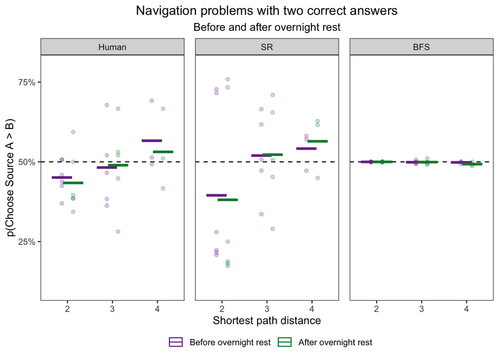

```r
plot_ties_before_after_overnight_rest
```

```r
if (knitting) {
  ggsave(
    here("figures", str_c("navigation_heldout_day1_to_day2", ".pdf")),
    plot = plot_ties_before_after_overnight_rest,
    width = 6, height = 4,
    units = "in", dpi = 300
  )
}
```

The BFS parameters tend to push predicted choice towards chance: the search threshold models an agent’s tendency to ‘give up’ and choose randomly during long searches, and the lapse rate models irreducible decision noise resulting in random choice. Here, we examine whether an unfettered, asymptotic BFS agent does a better job of mirroring human choice.

```r
plot_ties_asymptotic_bfs <- tie_item_analysis_humans %>%
  left_join(bfs_avg_accuracy_ties) %>%
  pivot_longer(
    starts_with("p_"),
    names_to = "agent",
    values_to = "p_choose_opt1"
  ) %>%
  mutate(
    agent = str_remove_all(agent, "p_|_opt1"),
    agent = case_when(
      agent == "human" ~ "Human",
      agent == "bfs" ~ "BFS",
    ),
    agent = fct_relevel(agent, "Human")
  ) %>%
  ggplot(aes(x=shortest_path, y=p_choose_opt1, color=measurement_id)) +
  theme_custom() +
  facet_wrap(~agent) +
  geom_hline(yintercept = 0.5, linetype = "dashed") +
  geom_point(
    alpha = 0.25, position = position_dodge(width = 0.5), show.legend = FALSE
  ) +
  stat_summary(
    aes(group=measurement_id),
    geom = "crossbar", fun = mean,
    position = position_dodge(width = 0.5)
  ) +
  scale_x_discrete(name = "Shortest path distance") +
  scale_y_continuous(
    name = "p(Choose Source A > B)",
    labels = scales::percent, breaks = seq(0, 1, 0.25)
  ) +
  scale_color_manual(
    name = NULL,
    labels = c("D1"="Before overnight rest", "D2"="After overnight rest"),
    values = c("D1"="#7b3294", "D2"="#008837")
  ) +
  coord_cartesian(ylim = c(0.1, 0.8)) +
  theme(
    panel.grid = element_blank(),
    legend.position = "bottom"
  ) +
  ggtitle(
    "Navigation problems with two correct answers",
    subtitle = "Asymptotic BFS agent"
  )
```

[output not shown]

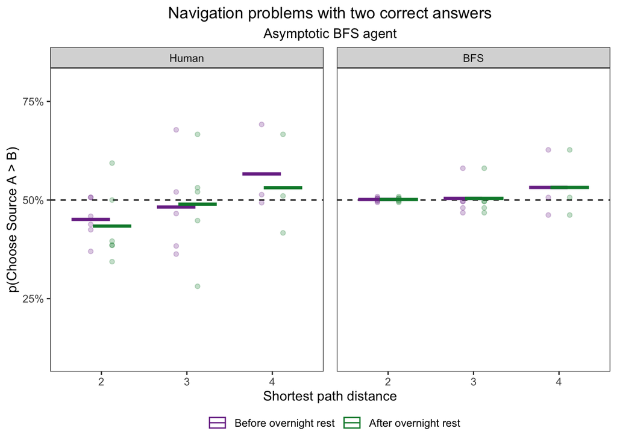

```r
plot_ties_asymptotic_bfs
```

```r
if (knitting) {
  ggsave(
    here("figures", str_c("navigation_heldout_asymptotic_bfs", ".pdf")),
    plot = plot_ties_asymptotic_bfs,
    width = 4, height = 4,
    units = "in", dpi = 300
  )
}
```